# Risk Factor Analysis

## Outcome Variable

**Outcome Variable:** swasted

## Predictor Variables

**Intervention Variable:** brthmon

**Adjustment Set:**

unadjusted

## Stratifying Variables

The analysis was stratified on these variable(s):

- agecat
- studyid
- country

## Data Summary

| agecat | studyid | country | brthmon | swasted | n_cell | n |
| --- | --- | --- | --- | --- | --- | --- |
| Birth | ki0047075b-MAL-ED | BANGLADESH | 1 | 0 | 19 | 241 |
| Birth | ki0047075b-MAL-ED | BANGLADESH | 1 | 1 | 0 | 241 |
| Birth | ki0047075b-MAL-ED | BANGLADESH | 2 | 0 | 23 | 241 |
| Birth | ki0047075b-MAL-ED | BANGLADESH | 2 | 1 | 0 | 241 |
| Birth | ki0047075b-MAL-ED | BANGLADESH | 3 | 0 | 20 | 241 |
| Birth | ki0047075b-MAL-ED | BANGLADESH | 3 | 1 | 2 | 241 |
| Birth | ki0047075b-MAL-ED | BANGLADESH | 4 | 0 | 19 | 241 |
| Birth | ki0047075b-MAL-ED | BANGLADESH | 4 | 1 | 2 | 241 |
| Birth | ki0047075b-MAL-ED | BANGLADESH | 5 | 0 | 20 | 241 |
| Birth | ki0047075b-MAL-ED | BANGLADESH | 5 | 1 | 0 | 241 |
| Birth | ki0047075b-MAL-ED | BANGLADESH | 6 | 0 | 10 | 241 |
| Birth | ki0047075b-MAL-ED | BANGLADESH | 6 | 1 | 0 | 241 |
| Birth | ki0047075b-MAL-ED | BANGLADESH | 7 | 0 | 19 | 241 |
| Birth | ki0047075b-MAL-ED | BANGLADESH | 7 | 1 | 0 | 241 |
| Birth | ki0047075b-MAL-ED | BANGLADESH | 8 | 0 | 22 | 241 |
| Birth | ki0047075b-MAL-ED | BANGLADESH | 8 | 1 | 1 | 241 |
| Birth | ki0047075b-MAL-ED | BANGLADESH | 9 | 0 | 18 | 241 |
| Birth | ki0047075b-MAL-ED | BANGLADESH | 9 | 1 | 1 | 241 |
| Birth | ki0047075b-MAL-ED | BANGLADESH | 10 | 0 | 23 | 241 |
| Birth | ki0047075b-MAL-ED | BANGLADESH | 10 | 1 | 1 | 241 |
| Birth | ki0047075b-MAL-ED | BANGLADESH | 11 | 0 | 15 | 241 |
| Birth | ki0047075b-MAL-ED | BANGLADESH | 11 | 1 | 0 | 241 |
| Birth | ki0047075b-MAL-ED | BANGLADESH | 12 | 0 | 25 | 241 |
| Birth | ki0047075b-MAL-ED | BANGLADESH | 12 | 1 | 1 | 241 |
| Birth | ki0047075b-MAL-ED | BRAZIL | 1 | 0 | 10 | 183 |
| Birth | ki0047075b-MAL-ED | BRAZIL | 1 | 1 | 0 | 183 |
| Birth | ki0047075b-MAL-ED | BRAZIL | 2 | 0 | 18 | 183 |
| Birth | ki0047075b-MAL-ED | BRAZIL | 2 | 1 | 0 | 183 |
| Birth | ki0047075b-MAL-ED | BRAZIL | 3 | 0 | 17 | 183 |
| Birth | ki0047075b-MAL-ED | BRAZIL | 3 | 1 | 0 | 183 |

[output cut: 1698 more lines]

The following strata were considered:

- agecat: 24 months, studyid: ki0047075b-MAL-ED, country: BANGLADESH
- agecat: 24 months, studyid: ki0047075b-MAL-ED, country: BRAZIL
- agecat: 24 months, studyid: ki0047075b-MAL-ED, country: INDIA
- agecat: 24 months, studyid: ki0047075b-MAL-ED, country: NEPAL
- agecat: 24 months, studyid: ki0047075b-MAL-ED, country: PERU
- agecat: 24 months, studyid: ki0047075b-MAL-ED, country: SOUTH AFRICA
- agecat: 24 months, studyid: ki0047075b-MAL-ED, country: TANZANIA, UNITED REPUBLIC OF
- agecat: 24 months, studyid: ki1000108-CMC-V-BCS-2002, country: INDIA
- agecat: 24 months, studyid: ki1000108-IRC, country: INDIA
- agecat: 24 months, studyid: ki1017093-NIH-Birth, country: BANGLADESH
- agecat: 24 months, studyid: ki1066203-TanzaniaChild2, country: TANZANIA, UNITED REPUBLIC OF
- agecat: 24 months, studyid: ki1101329-Keneba, country: GAMBIA
- agecat: 24 months, studyid: ki1113344-GMS-Nepal, country: NEPAL
- agecat: 24 months, studyid: ki1114097-CMIN, country: BANGLADESH
- agecat: 24 months, studyid: ki1114097-CMIN, country: GUINEA-BISSAU
- agecat: 24 months, studyid: ki1114097-CMIN, country: PERU
- agecat: 24 months, studyid: ki1114097-CONTENT, country: PERU
- agecat: 24 months, studyid: ki1119695-PROBIT, country: BELARUS
- agecat: 24 months, studyid: ki1126311-ZVITAMBO, country: ZIMBABWE
- agecat: 24 months, studyid: ki1148112-LCNI-5, country: MALAWI
- agecat: 24 months, studyid: kiGH5241-JiVitA-3, country: BANGLADESH
- agecat: 24 months, studyid: kiGH5241-JiVitA-4, country: BANGLADESH
- agecat: 6 months, studyid: ki0047075b-MAL-ED, country: BANGLADESH
- agecat: 6 months, studyid: ki0047075b-MAL-ED, country: BRAZIL
- agecat: 6 months, studyid: ki0047075b-MAL-ED, country: INDIA
- agecat: 6 months, studyid: ki0047075b-MAL-ED, country: NEPAL
- agecat: 6 months, studyid: ki0047075b-MAL-ED, country: PERU
- agecat: 6 months, studyid: ki0047075b-MAL-ED, country: SOUTH AFRICA
- agecat: 6 months, studyid: ki0047075b-MAL-ED, country: TANZANIA, UNITED REPUBLIC OF
- agecat: 6 months, studyid: ki1000108-CMC-V-BCS-2002, country: INDIA
- agecat: 6 months, studyid: ki1000108-IRC, country: INDIA
- agecat: 6 months, studyid: ki1000109-EE, country: PAKISTAN
- agecat: 6 months, studyid: ki1000109-ResPak, country: PAKISTAN
- agecat: 6 months, studyid: ki1000304b-SAS-CompFeed, country: INDIA
- agecat: 6 months, studyid: ki1000304b-SAS-FoodSuppl, country: INDIA
- agecat: 6 months, studyid: ki1017093-NIH-Birth, country: BANGLADESH
- agecat: 6 months, studyid: ki1066203-TanzaniaChild2, country: TANZANIA, UNITED REPUBLIC OF
- agecat: 6 months, studyid: ki1101329-Keneba, country: GAMBIA
- agecat: 6 months, studyid: ki1112895-Guatemala BSC, country: GUATEMALA
- agecat: 6 months, studyid: ki1113344-GMS-Nepal, country: NEPAL
- agecat: 6 months, studyid: ki1114097-CMIN, country: BANGLADESH
- agecat: 6 months, studyid: ki1114097-CMIN, country: BRAZIL
- agecat: 6 months, studyid: ki1114097-CMIN, country: GUINEA-BISSAU
- agecat: 6 months, studyid: ki1114097-CMIN, country: PERU
- agecat: 6 months, studyid: ki1114097-CONTENT, country: PERU
- agecat: 6 months, studyid: ki1119695-PROBIT, country: BELARUS
- agecat: 6 months, studyid: ki1126311-ZVITAMBO, country: ZIMBABWE
- agecat: 6 months, studyid: ki1148112-LCNI-5, country: MALAWI
- agecat: 6 months, studyid: kiGH5241-JiVitA-3, country: BANGLADESH
- agecat: 6 months, studyid: kiGH5241-JiVitA-4, country: BANGLADESH
- agecat: Birth, studyid: ki0047075b-MAL-ED, country: BANGLADESH
- agecat: Birth, studyid: ki0047075b-MAL-ED, country: BRAZIL
- agecat: Birth, studyid: ki0047075b-MAL-ED, country: INDIA
- agecat: Birth, studyid: ki0047075b-MAL-ED, country: NEPAL
- agecat: Birth, studyid: ki0047075b-MAL-ED, country: PERU
- agecat: Birth, studyid: ki0047075b-MAL-ED, country: SOUTH AFRICA
- agecat: Birth, studyid: ki0047075b-MAL-ED, country: TANZANIA, UNITED REPUBLIC OF
- agecat: Birth, studyid: ki1000108-CMC-V-BCS-2002, country: INDIA
- agecat: Birth, studyid: ki1000108-IRC, country: INDIA
- agecat: Birth, studyid: ki1000109-EE, country: PAKISTAN
- agecat: Birth, studyid: ki1000109-ResPak, country: PAKISTAN
- agecat: Birth, studyid: ki1000304b-SAS-CompFeed, country: INDIA
- agecat: Birth, studyid: ki1017093-NIH-Birth, country: BANGLADESH
- agecat: Birth, studyid: ki1101329-Keneba, country: GAMBIA
- agecat: Birth, studyid: ki1114097-CMIN, country: BANGLADESH
- agecat: Birth, studyid: ki1114097-CMIN, country: BRAZIL
- agecat: Birth, studyid: ki1114097-CMIN, country: PERU
- agecat: Birth, studyid: ki1114097-CONTENT, country: PERU
- agecat: Birth, studyid: ki1119695-PROBIT, country: BELARUS
- agecat: Birth, studyid: ki1126311-ZVITAMBO, country: ZIMBABWE
- agecat: Birth, studyid: kiGH5241-JiVitA-3, country: BANGLADESH
- agecat: Birth, studyid: kiGH5241-JiVitA-4, country: BANGLADESH

### Dropped Strata

Some strata were dropped due to rare outcomes:

- agecat: Birth, studyid: ki0047075b-MAL-ED, country: BANGLADESH
- agecat: Birth, studyid: ki0047075b-MAL-ED, country: BRAZIL
- agecat: Birth, studyid: ki0047075b-MAL-ED, country: INDIA
- agecat: Birth, studyid: ki0047075b-MAL-ED, country: NEPAL
- agecat: Birth, studyid: ki0047075b-MAL-ED, country: PERU
- agecat: Birth, studyid: ki0047075b-MAL-ED, country: SOUTH AFRICA
- agecat: Birth, studyid: ki0047075b-MAL-ED, country: TANZANIA, UNITED REPUBLIC OF
- agecat: Birth, studyid: ki1000108-CMC-V-BCS-2002, country: INDIA
- agecat: Birth, studyid: ki1000108-IRC, country: INDIA
- agecat: Birth, studyid: ki1000109-EE, country: PAKISTAN
- agecat: Birth, studyid: ki1000109-ResPak, country: PAKISTAN
- agecat: Birth, studyid: ki1000304b-SAS-CompFeed, country: INDIA
- agecat: Birth, studyid: ki1017093-NIH-Birth, country: BANGLADESH
- agecat: Birth, studyid: ki1101329-Keneba, country: GAMBIA
- agecat: Birth, studyid: ki1114097-CMIN, country: BANGLADESH
- agecat: Birth, studyid: ki1114097-CMIN, country: BRAZIL
- agecat: Birth, studyid: ki1114097-CMIN, country: PERU
- agecat: Birth, studyid: ki1114097-CONTENT, country: PERU
- agecat: Birth, studyid: kiGH5241-JiVitA-4, country: BANGLADESH
- agecat: 6 months, studyid: ki0047075b-MAL-ED, country: BANGLADESH
- agecat: 6 months, studyid: ki0047075b-MAL-ED, country: BRAZIL
- agecat: 6 months, studyid: ki0047075b-MAL-ED, country: INDIA
- agecat: 6 months, studyid: ki0047075b-MAL-ED, country: NEPAL
- agecat: 6 months, studyid: ki0047075b-MAL-ED, country: PERU
- agecat: 6 months, studyid: ki0047075b-MAL-ED, country: SOUTH AFRICA
- agecat: 6 months, studyid: ki0047075b-MAL-ED, country: TANZANIA, UNITED REPUBLIC OF
- agecat: 6 months, studyid: ki1000108-CMC-V-BCS-2002, country: INDIA
- agecat: 6 months, studyid: ki1000108-IRC, country: INDIA
- agecat: 6 months, studyid: ki1000109-EE, country: PAKISTAN
- agecat: 6 months, studyid: ki1000109-ResPak, country: PAKISTAN
- agecat: 6 months, studyid: ki1000304b-SAS-CompFeed, country: INDIA
- agecat: 6 months, studyid: ki1000304b-SAS-FoodSuppl, country: INDIA
- agecat: 6 months, studyid: ki1017093-NIH-Birth, country: BANGLADESH
- agecat: 6 months, studyid: ki1066203-TanzaniaChild2, country: TANZANIA, UNITED REPUBLIC OF
- agecat: 6 months, studyid: ki1101329-Keneba, country: GAMBIA
- agecat: 6 months, studyid: ki1112895-Guatemala BSC, country: GUATEMALA
- agecat: 6 months, studyid: ki1113344-GMS-Nepal, country: NEPAL
- agecat: 6 months, studyid: ki1114097-CMIN, country: BANGLADESH
- agecat: 6 months, studyid: ki1114097-CMIN, country: BRAZIL
- agecat: 6 months, studyid: ki1114097-CMIN, country: GUINEA-BISSAU
- agecat: 6 months, studyid: ki1114097-CMIN, country: PERU
- agecat: 6 months, studyid: ki1114097-CONTENT, country: PERU
- agecat: 6 months, studyid: ki1119695-PROBIT, country: BELARUS
- agecat: 6 months, studyid: ki1126311-ZVITAMBO, country: ZIMBABWE
- agecat: 6 months, studyid: ki1148112-LCNI-5, country: MALAWI
- agecat: 6 months, studyid: kiGH5241-JiVitA-4, country: BANGLADESH
- agecat: 24 months, studyid: ki0047075b-MAL-ED, country: BANGLADESH
- agecat: 24 months, studyid: ki0047075b-MAL-ED, country: BRAZIL
- agecat: 24 months, studyid: ki0047075b-MAL-ED, country: INDIA
- agecat: 24 months, studyid: ki0047075b-MAL-ED, country: NEPAL
- agecat: 24 months, studyid: ki0047075b-MAL-ED, country: PERU
- agecat: 24 months, studyid: ki0047075b-MAL-ED, country: SOUTH AFRICA
- agecat: 24 months, studyid: ki0047075b-MAL-ED, country: TANZANIA, UNITED REPUBLIC OF
- agecat: 24 months, studyid: ki1000108-CMC-V-BCS-2002, country: INDIA
- agecat: 24 months, studyid: ki1000108-IRC, country: INDIA
- agecat: 24 months, studyid: ki1017093-NIH-Birth, country: BANGLADESH
- agecat: 24 months, studyid: ki1066203-TanzaniaChild2, country: TANZANIA, UNITED REPUBLIC OF
- agecat: 24 months, studyid: ki1101329-Keneba, country: GAMBIA
- agecat: 24 months, studyid: ki1113344-GMS-Nepal, country: NEPAL
- agecat: 24 months, studyid: ki1114097-CMIN, country: BANGLADESH
- agecat: 24 months, studyid: ki1114097-CMIN, country: GUINEA-BISSAU
- agecat: 24 months, studyid: ki1114097-CMIN, country: PERU
- agecat: 24 months, studyid: ki1114097-CONTENT, country: PERU
- agecat: 24 months, studyid: ki1119695-PROBIT, country: BELARUS
- agecat: 24 months, studyid: ki1126311-ZVITAMBO, country: ZIMBABWE
- agecat: 24 months, studyid: ki1148112-LCNI-5, country: MALAWI
- agecat: 24 months, studyid: kiGH5241-JiVitA-4, country: BANGLADESH

## Methods Detail

We’re interested in the causal parameters $E[Y_a]$ for all values of $a \in \mathcal{A}$. These parameters represent the mean outcome if, possibly contrary to fact, we intervened to set all units to have $A=a$. Under the randomization and positivity assumptions, these are identified by the statistical parameters $\psi_a=E_W[E_{Y|A,W}(Y|A=a,W)]$. In addition, we’re interested in the mean of $Y$, $E[Y]$ under no intervention (the observed mean). We will estimate these parameters by using SuperLearner to fit the relevant likelihood factors – $E_{Y|A,W}(Y|A=a,W)$ and $p(A=a|W)$, and then updating our likelihood fit using a joint TMLE.

For unadjusted analyses ($W=\{\}$), initial likelihoods were estimated using Lrnr_glm to estimate the simple $E(Y|A)$ and Lrnr_mean to estimate $p(A)$. For adjusted analyses, a small library containing Lrnr_glmnet, Lrnr_xgboost, and Lrnr_mean was used.

Having estimated these parameters, we will then use the delta method to estimate relative risks and attributable risks relative to a prespecified baseline level of $A$.

# Results Detail

## Results Plots

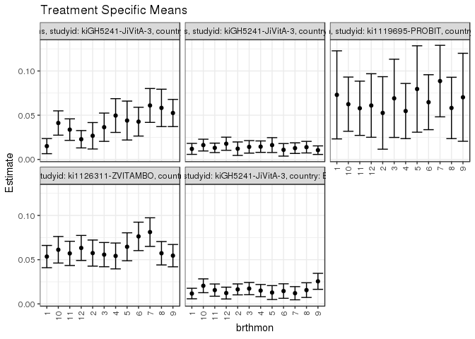

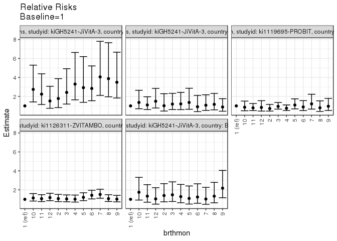

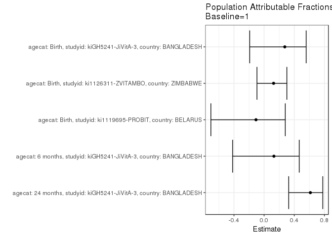

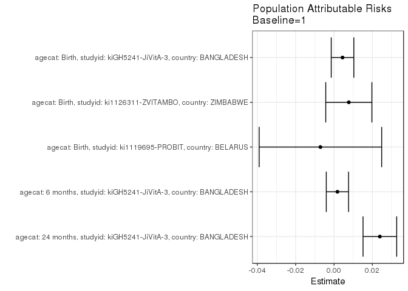

## Results Table

### Parameter: TSM

| agecat | studyid | country | intervention_level | baseline_level | estimate | ci_lower | ci_upper |
| --- | --- | --- | --- | --- | --- | --- | --- |
| Birth | ki1119695-PROBIT | BELARUS | 1 | NA | 0.0729927 | 0.0232126 | 0.1227728 |
| Birth | ki1119695-PROBIT | BELARUS | 2 | NA | 0.0525657 | 0.0115748 | 0.0935566 |
| Birth | ki1119695-PROBIT | BELARUS | 3 | NA | 0.0690755 | 0.0248616 | 0.1132893 |
| Birth | ki1119695-PROBIT | BELARUS | 4 | NA | 0.0546956 | 0.0234987 | 0.0858924 |
| Birth | ki1119695-PROBIT | BELARUS | 5 | NA | 0.0796178 | 0.0307804 | 0.1284553 |
| Birth | ki1119695-PROBIT | BELARUS | 6 | NA | 0.0647059 | 0.0336448 | 0.0957670 |
| Birth | ki1119695-PROBIT | BELARUS | 7 | NA | 0.0885781 | 0.0481392 | 0.1290170 |
| Birth | ki1119695-PROBIT | BELARUS | 8 | NA | 0.0581930 | 0.0234977 | 0.0928882 |
| Birth | ki1119695-PROBIT | BELARUS | 9 | NA | 0.0702417 | 0.0205076 | 0.1199758 |
| Birth | ki1119695-PROBIT | BELARUS | 10 | NA | 0.0624580 | 0.0317916 | 0.0931244 |
| Birth | ki1119695-PROBIT | BELARUS | 11 | NA | 0.0578453 | 0.0271874 | 0.0885031 |
| Birth | ki1119695-PROBIT | BELARUS | 12 | NA | 0.0609598 | 0.0250457 | 0.0968739 |
| Birth | ki1126311-ZVITAMBO | ZIMBABWE | 1 | NA | 0.0535280 | 0.0409640 | 0.0660920 |
| Birth | ki1126311-ZVITAMBO | ZIMBABWE | 2 | NA | 0.0574713 | 0.0427250 | 0.0722175 |
| Birth | ki1126311-ZVITAMBO | ZIMBABWE | 3 | NA | 0.0557103 | 0.0420117 | 0.0694089 |
| Birth | ki1126311-ZVITAMBO | ZIMBABWE | 4 | NA | 0.0542299 | 0.0396111 | 0.0688487 |
| Birth | ki1126311-ZVITAMBO | ZIMBABWE | 5 | NA | 0.0645856 | 0.0487794 | 0.0803918 |
| Birth | ki1126311-ZVITAMBO | ZIMBABWE | 6 | NA | 0.0763359 | 0.0602589 | 0.0924129 |
| Birth | ki1126311-ZVITAMBO | ZIMBABWE | 7 | NA | 0.0812044 | 0.0650326 | 0.0973762 |
| Birth | ki1126311-ZVITAMBO | ZIMBABWE | 8 | NA | 0.0572873 | 0.0440665 | 0.0705081 |
| Birth | ki1126311-ZVITAMBO | ZIMBABWE | 9 | NA | 0.0545746 | 0.0419617 | 0.0671875 |
| Birth | ki1126311-ZVITAMBO | ZIMBABWE | 10 | NA | 0.0612245 | 0.0462140 | 0.0762350 |
| Birth | ki1126311-ZVITAMBO | ZIMBABWE | 11 | NA | 0.0571170 | 0.0434211 | 0.0708128 |
| Birth | ki1126311-ZVITAMBO | ZIMBABWE | 12 | NA | 0.0632689 | 0.0491241 | 0.0774137 |
| Birth | kiGH5241-JiVitA-3 | BANGLADESH | 1 | NA | 0.0117322 | 0.0057854 | 0.0176791 |
| Birth | kiGH5241-JiVitA-3 | BANGLADESH | 2 | NA | 0.0164191 | 0.0102255 | 0.0226127 |
| Birth | kiGH5241-JiVitA-3 | BANGLADESH | 3 | NA | 0.0173188 | 0.0103813 | 0.0242563 |
| Birth | kiGH5241-JiVitA-3 | BANGLADESH | 4 | NA | 0.0150576 | 0.0081695 | 0.0219457 |
| Birth | kiGH5241-JiVitA-3 | BANGLADESH | 5 | NA | 0.0128535 | 0.0049817 | 0.0207253 |
| Birth | kiGH5241-JiVitA-3 | BANGLADESH | 6 | NA | 0.0145455 | 0.0063419 | 0.0227490 |
| Birth | kiGH5241-JiVitA-3 | BANGLADESH | 7 | NA | 0.0121012 | 0.0046487 | 0.0195537 |
| Birth | kiGH5241-JiVitA-3 | BANGLADESH | 8 | NA | 0.0156122 | 0.0073076 | 0.0239167 |
| Birth | kiGH5241-JiVitA-3 | BANGLADESH | 9 | NA | 0.0255236 | 0.0164792 | 0.0345679 |
| Birth | kiGH5241-JiVitA-3 | BANGLADESH | 10 | NA | 0.0204943 | 0.0126789 | 0.0283097 |
| Birth | kiGH5241-JiVitA-3 | BANGLADESH | 11 | NA | 0.0156250 | 0.0087031 | 0.0225469 |
| Birth | kiGH5241-JiVitA-3 | BANGLADESH | 12 | NA | 0.0122592 | 0.0055757 | 0.0189427 |
| 6 months | kiGH5241-JiVitA-3 | BANGLADESH | 1 | NA | 0.0119225 | 0.0057159 | 0.0181291 |
| 6 months | kiGH5241-JiVitA-3 | BANGLADESH | 2 | NA | 0.0121317 | 0.0045087 | 0.0197547 |
| 6 months | kiGH5241-JiVitA-3 | BANGLADESH | 3 | NA | 0.0141945 | 0.0071317 | 0.0212572 |
| 6 months | kiGH5241-JiVitA-3 | BANGLADESH | 4 | NA | 0.0144312 | 0.0079813 | 0.0208811 |
| 6 months | kiGH5241-JiVitA-3 | BANGLADESH | 5 | NA | 0.0162162 | 0.0078034 | 0.0246290 |
| 6 months | kiGH5241-JiVitA-3 | BANGLADESH | 6 | NA | 0.0108514 | 0.0037497 | 0.0179532 |
| 6 months | kiGH5241-JiVitA-3 | BANGLADESH | 7 | NA | 0.0127490 | 0.0067604 | 0.0187376 |
| 6 months | kiGH5241-JiVitA-3 | BANGLADESH | 8 | NA | 0.0138614 | 0.0073147 | 0.0204081 |
| 6 months | kiGH5241-JiVitA-3 | BANGLADESH | 9 | NA | 0.0104874 | 0.0056538 | 0.0153209 |
| 6 months | kiGH5241-JiVitA-3 | BANGLADESH | 10 | NA | 0.0162162 | 0.0095711 | 0.0228614 |
| 6 months | kiGH5241-JiVitA-3 | BANGLADESH | 11 | NA | 0.0130756 | 0.0077310 | 0.0184202 |
| 6 months | kiGH5241-JiVitA-3 | BANGLADESH | 12 | NA | 0.0177440 | 0.0103159 | 0.0251720 |
| 24 months | kiGH5241-JiVitA-3 | BANGLADESH | 1 | NA | 0.0150376 | 0.0065061 | 0.0235691 |
| 24 months | kiGH5241-JiVitA-3 | BANGLADESH | 2 | NA | 0.0267380 | 0.0117858 | 0.0416901 |
| 24 months | kiGH5241-JiVitA-3 | BANGLADESH | 3 | NA | 0.0364146 | 0.0204289 | 0.0524002 |
| 24 months | kiGH5241-JiVitA-3 | BANGLADESH | 4 | NA | 0.0496032 | 0.0305132 | 0.0686931 |
| 24 months | kiGH5241-JiVitA-3 | BANGLADESH | 5 | NA | 0.0439560 | 0.0219593 | 0.0659528 |
| 24 months | kiGH5241-JiVitA-3 | BANGLADESH | 6 | NA | 0.0426929 | 0.0264160 | 0.0589699 |
| 24 months | kiGH5241-JiVitA-3 | BANGLADESH | 7 | NA | 0.0610119 | 0.0418540 | 0.0801698 |
| 24 months | kiGH5241-JiVitA-3 | BANGLADESH | 8 | NA | 0.0582524 | 0.0371450 | 0.0793599 |
| 24 months | kiGH5241-JiVitA-3 | BANGLADESH | 9 | NA | 0.0525000 | 0.0371451 | 0.0678549 |
| 24 months | kiGH5241-JiVitA-3 | BANGLADESH | 10 | NA | 0.0411899 | 0.0274588 | 0.0549210 |
| 24 months | kiGH5241-JiVitA-3 | BANGLADESH | 11 | NA | 0.0336862 | 0.0215250 | 0.0458475 |
| 24 months | kiGH5241-JiVitA-3 | BANGLADESH | 12 | NA | 0.0228233 | 0.0130096 | 0.0326371 |

### Parameter: E(Y)

| agecat | studyid | country | intervention_level | baseline_level | estimate | ci_lower | ci_upper |
| --- | --- | --- | --- | --- | --- | --- | --- |
| Birth | ki1119695-PROBIT | BELARUS | NA | NA | 0.0658999 | 0.0328405 | 0.0989593 |
| Birth | ki1126311-ZVITAMBO | ZIMBABWE | NA | NA | 0.0612419 | 0.0571066 | 0.0653771 |
| Birth | kiGH5241-JiVitA-3 | BANGLADESH | NA | NA | 0.0161691 | 0.0138058 | 0.0185324 |
| 6 months | kiGH5241-JiVitA-3 | BANGLADESH | NA | NA | 0.0137035 | 0.0116269 | 0.0157801 |
| 24 months | kiGH5241-JiVitA-3 | BANGLADESH | NA | NA | 0.0389399 | 0.0346167 | 0.0432631 |

### Parameter: RR

| agecat | studyid | country | intervention_level | baseline_level | estimate | ci_lower | ci_upper |
| --- | --- | --- | --- | --- | --- | --- | --- |
| Birth | ki1119695-PROBIT | BELARUS | 1 | 1 | 1.0000000 | 1.0000000 | 1.000000 |
| Birth | ki1119695-PROBIT | BELARUS | 2 | 1 | 0.7201502 | 0.4486025 | 1.156071 |
| Birth | ki1119695-PROBIT | BELARUS | 3 | 1 | 0.9463337 | 0.6583751 | 1.360239 |
| Birth | ki1119695-PROBIT | BELARUS | 4 | 1 | 0.7493292 | 0.5101932 | 1.100552 |
| Birth | ki1119695-PROBIT | BELARUS | 5 | 1 | 1.0907643 | 0.6823302 | 1.743682 |
| Birth | ki1119695-PROBIT | BELARUS | 6 | 1 | 0.8864706 | 0.5043755 | 1.558026 |
| Birth | ki1119695-PROBIT | BELARUS | 7 | 1 | 1.2135198 | 0.6601137 | 2.230874 |
| Birth | ki1119695-PROBIT | BELARUS | 8 | 1 | 0.7972435 | 0.4148578 | 1.532084 |
| Birth | ki1119695-PROBIT | BELARUS | 9 | 1 | 0.9623112 | 0.5167545 | 1.792036 |
| Birth | ki1119695-PROBIT | BELARUS | 10 | 1 | 0.8556749 | 0.4862109 | 1.505889 |
| Birth | ki1119695-PROBIT | BELARUS | 11 | 1 | 0.7924801 | 0.5018575 | 1.251400 |
| Birth | ki1119695-PROBIT | BELARUS | 12 | 1 | 0.8351492 | 0.4497695 | 1.550737 |
| Birth | ki1126311-ZVITAMBO | ZIMBABWE | 1 | 1 | 1.0000000 | 1.0000000 | 1.000000 |
| Birth | ki1126311-ZVITAMBO | ZIMBABWE | 2 | 1 | 1.0736677 | 0.7583069 | 1.520179 |
| Birth | ki1126311-ZVITAMBO | ZIMBABWE | 3 | 1 | 1.0407698 | 0.7408383 | 1.462130 |
| Birth | ki1126311-ZVITAMBO | ZIMBABWE | 4 | 1 | 1.0131138 | 0.7086396 | 1.448408 |
| Birth | ki1126311-ZVITAMBO | ZIMBABWE | 5 | 1 | 1.2065760 | 0.8595811 | 1.693645 |
| Birth | ki1126311-ZVITAMBO | ZIMBABWE | 6 | 1 | 1.4260930 | 1.0403774 | 1.954811 |
| Birth | ki1126311-ZVITAMBO | ZIMBABWE | 7 | 1 | 1.5170455 | 1.1151006 | 2.063874 |
| Birth | ki1126311-ZVITAMBO | ZIMBABWE | 8 | 1 | 1.0702305 | 0.7700534 | 1.487421 |
| Birth | ki1126311-ZVITAMBO | ZIMBABWE | 9 | 1 | 1.0195535 | 0.7334195 | 1.417319 |
| Birth | ki1126311-ZVITAMBO | ZIMBABWE | 10 | 1 | 1.1437848 | 0.8145894 | 1.606016 |
| Birth | ki1126311-ZVITAMBO | ZIMBABWE | 11 | 1 | 1.0670485 | 0.7628852 | 1.492482 |
| Birth | ki1126311-ZVITAMBO | ZIMBABWE | 12 | 1 | 1.1819779 | 0.8547359 | 1.634507 |
| Birth | kiGH5241-JiVitA-3 | BANGLADESH | 1 | 1 | 1.0000000 | 1.0000000 | 1.000000 |
| Birth | kiGH5241-JiVitA-3 | BANGLADESH | 2 | 1 | 1.3994849 | 0.7382020 | 2.653147 |
| Birth | kiGH5241-JiVitA-3 | BANGLADESH | 3 | 1 | 1.4761725 | 0.7678535 | 2.837892 |
| Birth | kiGH5241-JiVitA-3 | BANGLADESH | 4 | 1 | 1.2834367 | 0.6416246 | 2.567248 |
| Birth | kiGH5241-JiVitA-3 | BANGLADESH | 5 | 1 | 1.0955693 | 0.4984826 | 2.407852 |
| Birth | kiGH5241-JiVitA-3 | BANGLADESH | 6 | 1 | 1.2397861 | 0.5828211 | 2.637292 |
| Birth | kiGH5241-JiVitA-3 | BANGLADESH | 7 | 1 | 1.0314502 | 0.4705435 | 2.260980 |
| Birth | kiGH5241-JiVitA-3 | BANGLADESH | 8 | 1 | 1.3307071 | 0.6351210 | 2.788101 |
| Birth | kiGH5241-JiVitA-3 | BANGLADESH | 9 | 1 | 2.1755082 | 1.1688967 | 4.048977 |
| Birth | kiGH5241-JiVitA-3 | BANGLADESH | 10 | 1 | 1.7468354 | 0.9196699 | 3.317967 |
| Birth | kiGH5241-JiVitA-3 | BANGLADESH | 11 | 1 | 1.3318015 | 0.6960775 | 2.548129 |
| Birth | kiGH5241-JiVitA-3 | BANGLADESH | 12 | 1 | 1.0449160 | 0.4902653 | 2.227058 |
| 6 months | kiGH5241-JiVitA-3 | BANGLADESH | 1 | 1 | 1.0000000 | 1.0000000 | 1.000000 |
| 6 months | kiGH5241-JiVitA-3 | BANGLADESH | 2 | 1 | 1.0175477 | 0.4526386 | 2.287484 |
| 6 months | kiGH5241-JiVitA-3 | BANGLADESH | 3 | 1 | 1.1905607 | 0.6100720 | 2.323389 |
| 6 months | kiGH5241-JiVitA-3 | BANGLADESH | 4 | 1 | 1.2104202 | 0.6041013 | 2.425284 |
| 6 months | kiGH5241-JiVitA-3 | BANGLADESH | 5 | 1 | 1.3601351 | 0.6459664 | 2.863876 |
| 6 months | kiGH5241-JiVitA-3 | BANGLADESH | 6 | 1 | 0.9101628 | 0.3920957 | 2.112740 |
| 6 months | kiGH5241-JiVitA-3 | BANGLADESH | 7 | 1 | 1.0693227 | 0.5258902 | 2.174315 |
| 6 months | kiGH5241-JiVitA-3 | BANGLADESH | 8 | 1 | 1.1626238 | 0.5842250 | 2.313653 |
| 6 months | kiGH5241-JiVitA-3 | BANGLADESH | 9 | 1 | 0.8796268 | 0.4392935 | 1.761336 |
| 6 months | kiGH5241-JiVitA-3 | BANGLADESH | 10 | 1 | 1.3601351 | 0.6988876 | 2.647017 |
| 6 months | kiGH5241-JiVitA-3 | BANGLADESH | 11 | 1 | 1.0967169 | 0.6124994 | 1.963737 |
| 6 months | kiGH5241-JiVitA-3 | BANGLADESH | 12 | 1 | 1.4882763 | 0.7782042 | 2.846253 |
| 24 months | kiGH5241-JiVitA-3 | BANGLADESH | 1 | 1 | 1.0000000 | 1.0000000 | 1.000000 |
| 24 months | kiGH5241-JiVitA-3 | BANGLADESH | 2 | 1 | 1.7780743 | 0.8159792 | 3.874545 |
| 24 months | kiGH5241-JiVitA-3 | BANGLADESH | 3 | 1 | 2.4215679 | 1.1919846 | 4.919519 |
| 24 months | kiGH5241-JiVitA-3 | BANGLADESH | 4 | 1 | 3.2986101 | 1.6399879 | 6.634701 |
| 24 months | kiGH5241-JiVitA-3 | BANGLADESH | 5 | 1 | 2.9230761 | 1.3779216 | 6.200914 |
| 24 months | kiGH5241-JiVitA-3 | BANGLADESH | 6 | 1 | 2.8390796 | 1.5458669 | 5.214144 |
| 24 months | kiGH5241-JiVitA-3 | BANGLADESH | 7 | 1 | 4.0572905 | 2.1077979 | 7.809860 |
| 24 months | kiGH5241-JiVitA-3 | BANGLADESH | 8 | 1 | 3.8737853 | 1.9578932 | 7.664469 |
| 24 months | kiGH5241-JiVitA-3 | BANGLADESH | 9 | 1 | 3.4912490 | 1.8286855 | 6.665345 |
| 24 months | kiGH5241-JiVitA-3 | BANGLADESH | 10 | 1 | 2.7391296 | 1.4152884 | 5.301274 |
| 24 months | kiGH5241-JiVitA-3 | BANGLADESH | 11 | 1 | 2.2401341 | 1.1440631 | 4.386297 |
| 24 months | kiGH5241-JiVitA-3 | BANGLADESH | 12 | 1 | 1.5177510 | 0.7494849 | 3.073535 |

### Parameter: PAR

| agecat | studyid | country | intervention_level | baseline_level | estimate | ci_lower | ci_upper |
| --- | --- | --- | --- | --- | --- | --- | --- |
| Birth | ki1119695-PROBIT | BELARUS | 1 | NA | -0.0070928 | -0.0390314 | 0.0248458 |
| Birth | ki1126311-ZVITAMBO | ZIMBABWE | 1 | NA | 0.0077139 | -0.0043201 | 0.0197478 |
| Birth | kiGH5241-JiVitA-3 | BANGLADESH | 1 | NA | 0.0044368 | -0.0014564 | 0.0103301 |
| 6 months | kiGH5241-JiVitA-3 | BANGLADESH | 1 | NA | 0.0017810 | -0.0040277 | 0.0075898 |
| 24 months | kiGH5241-JiVitA-3 | BANGLADESH | 1 | NA | 0.0239023 | 0.0151282 | 0.0326765 |

### Parameter: PAF

| agecat | studyid | country | intervention_level | baseline_level | estimate | ci_lower | ci_upper |
| --- | --- | --- | --- | --- | --- | --- | --- |
| Birth | ki1119695-PROBIT | BELARUS | 1 | NA | -0.1076302 | -0.7057972 | 0.2807793 |
| Birth | ki1126311-ZVITAMBO | ZIMBABWE | 1 | NA | 0.1259578 | -0.0941772 | 0.3018043 |
| Birth | kiGH5241-JiVitA-3 | BANGLADESH | 1 | NA | 0.2744032 | -0.1909198 | 0.5579125 |
| 6 months | kiGH5241-JiVitA-3 | BANGLADESH | 1 | NA | 0.1299682 | -0.4175735 | 0.4660204 |
| 24 months | kiGH5241-JiVitA-3 | BANGLADESH | 1 | NA | 0.6138255 | 0.3264386 | 0.7785937 |